# usl_project_PartB

```python
import numpy as np
import pandas as pd
import matplotlib.pyplot as plt
import seaborn as sns

from sklearn.cluster import KMeans
from sklearn import metrics
from scipy.stats import zscore
from sklearn.model_selection import RandomizedSearchCV, GridSearchCV

from sklearn.svm import SVC
from sklearn.decomposition import PCA

import warnings
warnings.filterwarnings('ignore')
```

## 1. Data understanding and exploration

#### Q1 A Read the Data set “country_stats.csv” and print the shape of the dataset.

```python
data = pd.read_csv('country_stats.csv')
data_bkp = data.copy()
```

```python
data.shape
```

```
(229, 14)
```

```python
data.head()
```

|  | country | Region | Surface area | Population in thousands | Population density | GDP: Gross domestic product | Economy: Agriculture | Economy: Industry | Economy: Services and other activity | International trade: Balance | Health: Total expenditure | Education: Government expenditure | Mobile-cellular subscriptions | Individuals using the Internet |
| --- | --- | --- | --- | --- | --- | --- | --- | --- | --- | --- | --- | --- | --- | --- |
| 0 | Afghanistan | SouthernAsia | 652864.0 | 35530 | 54.4 | 20270.0 | 23.3 | 23.3 | 53.3 | -2110.0 | 8.2 | 3.3 | 61.6 | 42.0 |
| 1 | Albania | SouthernEurope | 28748.0 | 2930 | 106.9 | 11541.0 | 22.4 | 26.0 | 51.7 | -2707.0 | 5.9 | 3.5 | 106.4 | 130.0 |
| 2 | Algeria | NorthernAfrica | 2381741.0 | 41318 | 17.3 | 164779.0 | 12.2 | 37.3 | 50.5 | -17099.0 | 7.2 | NaN | 113.0 | 135.0 |
| 3 | American Samoa | Polynesia | 199.0 | 56 | 278.2 | NaN | NaN | NaN | NaN | NaN | NaN | NaN | NaN | 92.0 |
| 4 | Andorra | SouthernEurope | 468.0 | 77 | 163.8 | 2812.0 | 0.5 | 10.8 | 88.6 | -1255.0 | 8.1 | 3.3 | 88.1 | 13.0 |

```python
data.info()
```

```
<class 'pandas.core.frame.DataFrame'>
RangeIndex: 229 entries, 0 to 228
Data columns (total 14 columns):
 #   Column                                Non-Null Count  Dtype
---  ------                                --------------  -----
 0   country                               229 non-null    object
 1   Region                                229 non-null    object
 2   Surface area                          226 non-null    float64
 3   Population in thousands               229 non-null    int64
 4   Population density                    229 non-null    float64
 5   GDP: Gross domestic product           208 non-null    float64
 6   Economy: Agriculture                  206 non-null    float64
 7   Economy: Industry                     208 non-null    float64
 8   Economy: Services and other activity  208 non-null    float64
 9   International trade: Balance          210 non-null    float64
 10  Health: Total expenditure             190 non-null    float64
 11  Education: Government expenditure     148 non-null    float64
 12  Mobile-cellular subscriptions         209 non-null    float64
 13  Individuals using the Internet        228 non-null    float64
dtypes: float64(11), int64(1), object(2)
memory usage: 25.2+ KB
```

There are 14 columns, where 2 are objects and remaining are numeric columns. There are null values in many columns.

#### Q1 B Print 5 points summary statistics of the data and share your observations.

```python
data.describe().T
```

|  | count | mean | std | min | 25% | 50% | 75% | max |
| --- | --- | --- | --- | --- | --- | --- | --- | --- |
| Surface area | 226.0 | 593210.044248 | 1.796021e+06 | 0.00001 | 4306.500 | 83735.50 | 437693.500 | 17098246.0 |
| Population in thousands | 229.0 | 32756.794760 | 1.332751e+05 | 1.00000 | 431.000 | 5448.00 | 19193.000 | 1409517.0 |
| Population density | 229.0 | 462.824891 | 2.305384e+03 | 0.10000 | 35.900 | 88.10 | 222.800 | 25969.8 |
| GDP: Gross domestic product | 208.0 | 353896.341346 | 1.548160e+06 | 33.00000 | 4987.000 | 23871.00 | 174551.750 | 18036648.0 |
| Economy: Agriculture | 206.0 | 11.481553 | 1.210060e+01 | 0.00001 | 2.400 | 7.20 | 17.500 | 70.8 |
| Economy: Industry | 208.0 | 27.565385 | 1.312442e+01 | 4.00000 | 19.075 | 26.45 | 33.325 | 79.9 |
| Economy: Services and other activity | 208.0 | 61.089423 | 1.550489e+01 | 14.90000 | 51.000 | 61.30 | 72.100 | 94.0 |
| International trade: Balance | 210.0 | -683.861905 | 7.318817e+04 | -796494.00000 | -3501.250 | -984.00 | 49.250 | 530285.0 |
| Health: Total expenditure | 190.0 | 6.763158 | 2.798017e+00 | 1.50000 | 4.825 | 6.35 | 8.375 | 17.1 |
| Education: Government expenditure | 148.0 | 4.570946 | 1.781128e+00 | 1.00000 | 3.200 | 4.55 | 5.500 | 12.5 |
| Mobile-cellular subscriptions | 209.0 | 107.360287 | 4.306386e+01 | 7.00000 | 79.400 | 108.20 | 130.600 | 324.4 |
| Individuals using the Internet | 228.0 | 200.017544 | 2.964446e+02 | 1.00000 | 55.750 | 97.50 | 196.250 | 2358.0 |

##### Observation:

Surface Area:

The mean surface area is quite large (593,210.044248), but there's a significant range from the minimum (0.00001) to the maximum (17,098,246.0). This suggests a high variation in country sizes. The substantial standard deviation (1,796,021) also indicates a wide distribution in surface area.

Population in Thousands:

The mean population is 32,756.794760, with a considerable range from 1.0 to 1,409,517.0. The high standard deviation (133,275.1) suggests large differences in population sizes among the countries.

Population Density:

The mean population density is 462.824891, but there's a significant variance indicated by the standard deviation (2,305.384). The wide range (0.1 to 25,969.8) points to diverse population densities in different regions.

GDP (Gross Domestic Product):

The mean GDP is 353,896.341346, with a large standard deviation (1,548,160.0), indicating substantial economic diversity. The range (33.0 to 18,036,648.0) highlights the varying economic scales across countries.

Economy: Agriculture:

The mean percentage of the economy attributed to agriculture is 11.481553, with a standard deviation of 12.10060. This indicates a range of agricultural contributions, from almost negligible (0.00001) to quite significant (70.8).

Economy: Industry:

The mean contribution of industry to the economy is 27.565385, with a standard deviation of 13.12442. The range (4.0 to 79.9) shows varying levels of industrial activity.

Economy: Services and Other Activities:

International Trade: Balance:

The mean balance of trade is negative (-683.861905), indicating a trade deficit. The high standard deviation (73,188.17) and range (-796,494.0 to 530,285.0) suggest significant variations in trade balances.

Health: Total Expenditure:

The mean total health expenditure is 6.763158, with a relatively smaller standard deviation (2.798017). The range (1.5 to 17.1) shows varying investment levels in health.

Education: Government Expenditure:

The mean government expenditure on education is 4.570946, with a standard deviation of 1.781128. The range (1.0 to 12.5) indicates different levels of commitment to education funding.

Mobile-Cellular Subscriptions:

The mean number of mobile-cellular subscriptions is 107.360287, with a standard deviation of 43.06386. The range (7.0 to 324.4) highlights disparities in mobile penetration.

Individuals Using the Internet:

The mean percentage of individuals using the internet is 200.017544, with a high standard deviation (296.4446). The range (1.0 to 2,358.0) points to diverse levels of internet access.

#### Q2 A Perform Univariate Analysis on the data and find out which country has more population as per 2017. (Hint: plot population in thousand and country to know which country has more population)

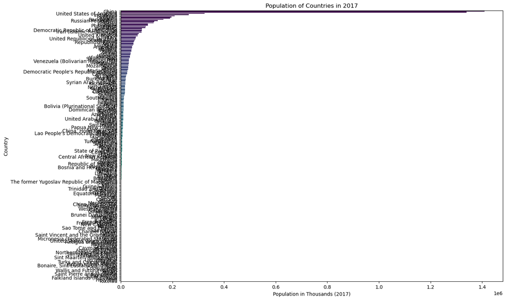

```python
df_sorted = data.sort_values(by='Population in thousands', ascending=False)

# Plot the bar chart using Seaborn
plt.figure(figsize=(14, 10))
sns.barplot(x='Population in thousands', y='country', data=df_sorted, palette='viridis')
plt.xlabel('Population in Thousands (2017)')
plt.ylabel('Country')
plt.title('Population of Countries in 2017')
plt.show()
```

```python
data.sort_values(by='Population in thousands', ascending=False)['country']
```

```
45                           China
95                           India
217       United States of America
96                       Indonesia
28                          Brazil
                  ...
169                   Saint Helena
68     Falkland Islands (Malvinas)
149                           Niue
91                        Holy See
204                        Tokelau
Name: country, Length: 229, dtype: object
```

#### As per 2017, China has the highest population

#### Q2 B Perform bivariate and multivariate analysis and share your insights. Any 2 plots which explains the relationship better.

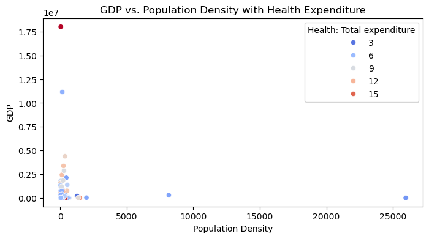

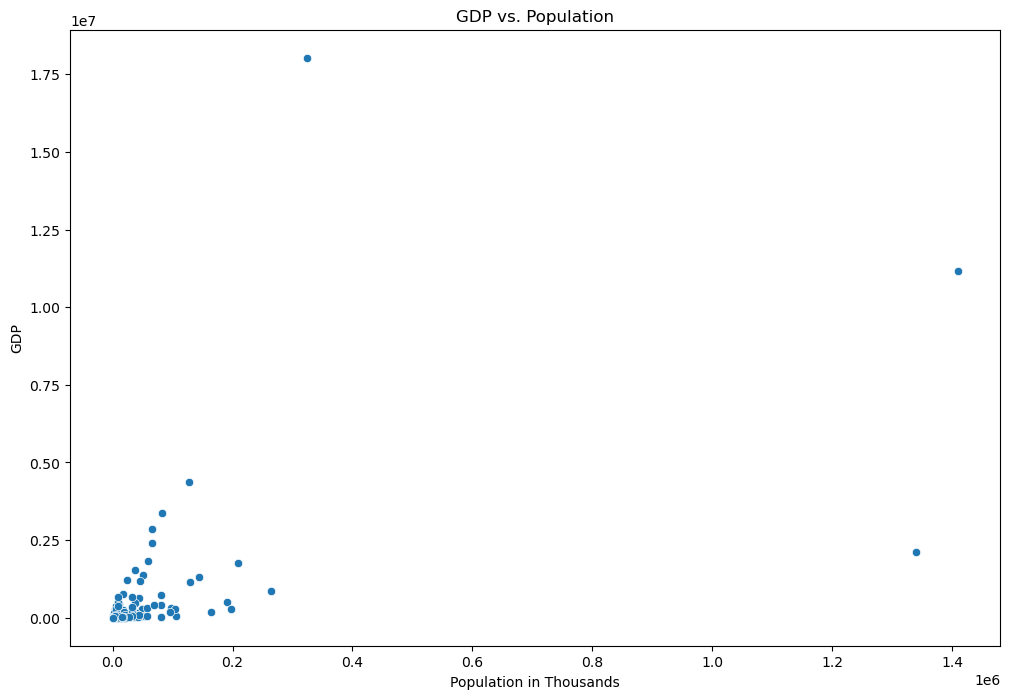

```python
# GDP vs. Population Density with a third variable (color-coded) for Health Expenditure

plt.figure(figsize=(8,4))
sns.scatterplot(x='Population density', y='GDP: Gross domestic product', hue='Health: Total expenditure', palette='coolwarm', data=data)
plt.xlabel('Population Density')
plt.ylabel('GDP')
plt.title('GDP vs. Population Density with Health Expenditure')
plt.show();

# Scatter plot: GDP vs. Population
plt.figure(figsize=(12, 8))
sns.scatterplot(x='Population in thousands', y='GDP: Gross domestic product', data=data)
plt.xlabel('Population in Thousands')
plt.ylabel('GDP')
plt.title('GDP vs. Population')
plt.show()
```

##### Observations:

1. Most data points are clustered in the lower-left corner, indicating that many countries have relatively low populations and GDPs. This suggests that a large number of countries have smaller economies and smaller populations.
2. A general positive correlation between population size and GDP. As the population increases, GDP tends to increase as well. This suggests that countries with larger populations often have larger economies, possibly due to greater workforce, consumption, and production capabilities.
3. The majority of data points are in lighter blue and light red colors, indicating low to moderate health expenditures. This suggests that most countries spend a smaller portion of their GDP on health.
4. Countries with moderate GDP values are scattered across different population densities. Their health expenditures range from low to high, as indicated by the color gradient. There is no clear trend suggesting that higher health expenditure directly correlates with higher GDP.

#### Q3 A Check if the data has any missing values, if any, impute those with suitable approach

```python
data.isnull().sum()
```

```
country                                  0
Region                                   0
Surface area                             3
Population in thousands                  0
Population density                       0
GDP: Gross domestic product             21
Economy: Agriculture                    23
Economy: Industry                       21
Economy: Services and other activity    21
International trade: Balance            19
Health: Total expenditure               39
Education: Government expenditure       81
Mobile-cellular subscriptions           20
Individuals using the Internet           1
dtype: int64
```

```python
#Imputing the null values with appropriate technique
data['Surface area'].fillna(data['Surface area'].median(), inplace=True)
data['GDP: Gross domestic product'].fillna(data['GDP: Gross domestic product'].median(), inplace=True)
data['Economy: Agriculture'].fillna(data['Economy: Agriculture'].median(), inplace=True)
data['Economy: Industry'].fillna(data['Economy: Industry'].median(), inplace=True)
data['Economy: Services and other activity'].fillna(data['Economy: Services and other activity'].median(), inplace=True)
data['International trade: Balance'].fillna(data['International trade: Balance'].median(), inplace=True)
data['Health: Total expenditure'].fillna(data['Health: Total expenditure'].median(), inplace=True)
data['Education: Government expenditure'].fillna(data['Education: Government expenditure'].median(), inplace=True)
data['Mobile-cellular subscriptions'].fillna(data['Mobile-cellular subscriptions'].median(), inplace=True)
data['Individuals using the Internet'].fillna(data['Individuals using the Internet'].median(), inplace=True)
```

```python
data.isnull().sum()
```

```
country                                 0
Region                                  0
Surface area                            0
Population in thousands                 0
Population density                      0
GDP: Gross domestic product             0
Economy: Agriculture                    0
Economy: Industry                       0
Economy: Services and other activity    0
International trade: Balance            0
Health: Total expenditure               0
Education: Government expenditure       0
Mobile-cellular subscriptions           0
Individuals using the Internet          0
dtype: int64
```

#### Q3 B Scale all the numeric variables in the data.

```python
from sklearn.preprocessing import StandardScaler
# Identify numeric columns
numeric_cols = data.select_dtypes(include=['float64', 'int64']).columns
data_for_model = data[numeric_cols]
# Initialize the scaler
scaler = StandardScaler()

# Scale the numeric columns
data_for_model = pd.DataFrame(scaler.fit_transform(data[numeric_cols]),columns=numeric_cols)
```

```python
data_for_model.head()
```

|  | Surface area | Population in thousands | Population density | GDP: Gross domestic product | Economy: Agriculture | Economy: Industry | Economy: Services and other activity | International trade: Balance | Health: Total expenditure | Education: Government expenditure | Mobile-cellular subscriptions | Individuals using the Internet |
| --- | --- | --- | --- | --- | --- | --- | --- | --- | --- | --- | --- | --- |
| 0 | 0.037238 | 0.020854 | -0.177549 | -0.205670 | 1.063137 | -0.333522 | -0.529713 | -0.020041 | 0.591834 | -0.885404 | -1.116735 | -0.533729 |
| 1 | -0.313151 | -0.224289 | -0.154727 | -0.211588 | 0.985019 | -0.117215 | -0.638251 | -0.028579 | -0.311306 | -0.745257 | -0.025184 | -0.235651 |
| 2 | 1.007858 | 0.064378 | -0.193677 | -0.107697 | 0.099684 | 0.788072 | -0.719654 | -0.234417 | 0.199164 | -0.009486 | 0.135625 | -0.218714 |
| 3 | -0.329179 | -0.245901 | -0.080260 | -0.203229 | -0.334303 | -0.081163 | 0.012975 | -0.003936 | -0.134605 | -0.009486 | 0.018673 | -0.364366 |
| 4 | -0.329028 | -0.245743 | -0.129991 | -0.217506 | -0.915846 | -1.334946 | 1.864897 | -0.007812 | 0.552567 | -0.885404 | -0.471063 | -0.631959 |

#### Q4 A Apply Hierarchical clustering to the scaled data.

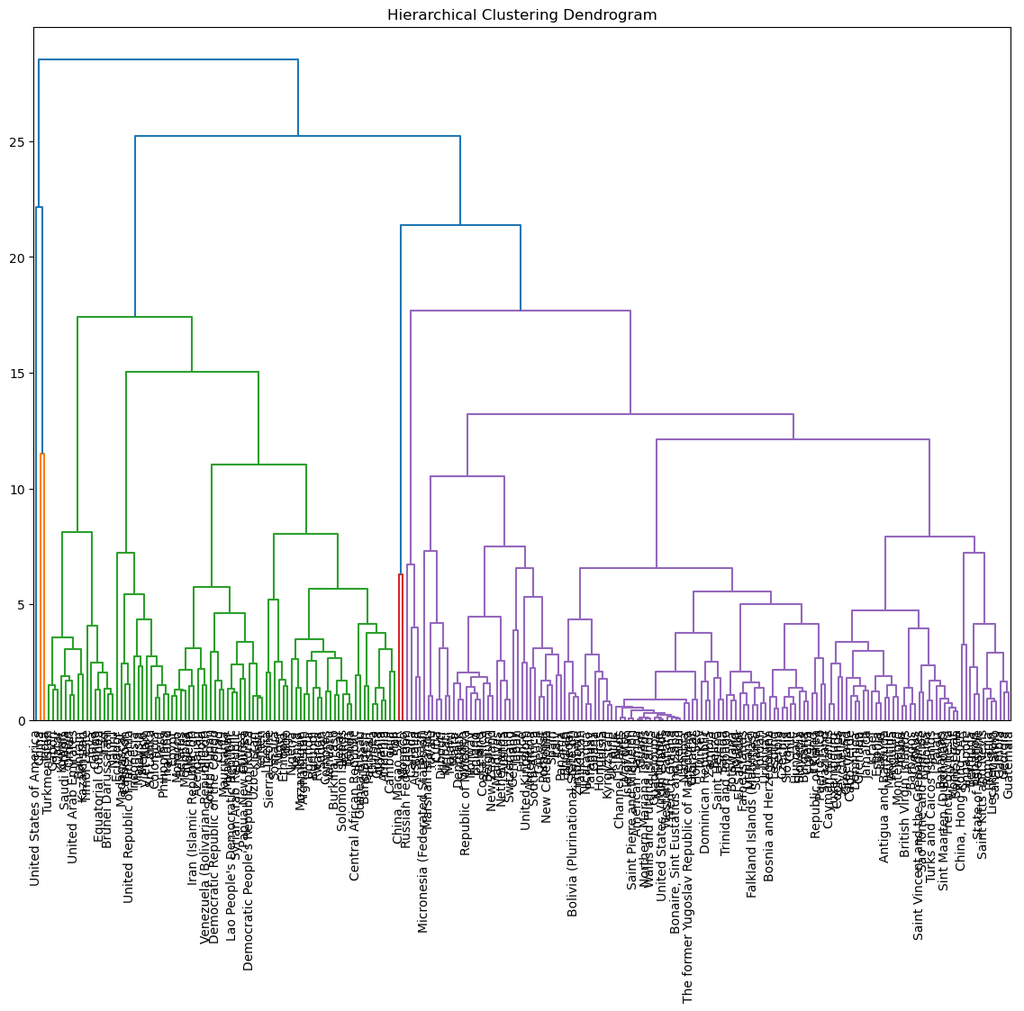

```python
from scipy.cluster.hierarchy import dendrogram, linkage,fcluster

Z = linkage(data_for_model, method='ward')

plt.figure(figsize=(14, 10))
dendrogram(Z, labels=data['country'].values, leaf_rotation=90, leaf_font_size=10)
plt.title('Hierarchical Clustering Dendrogram')
plt.show()
```

### Insights

#### Q4 C Do Cluster profiling and display.

#### Q4 D Share your insights on cluster profiles and also give any 2 business recommendations.

```python
num_clusters = 5
cluster_labels = fcluster(Z, num_clusters, criterion='maxclust')
print("Cluster labels assigned: ", cluster_labels[:10])
# Add cluster labels to the original data
data['Cluster'] = cluster_labels

data.head()
```

```
Cluster labels assigned:  [3 3 3 5 5 3 5 5 5 3]
```

|  | country | Region | Surface area | Population in thousands | Population density | GDP: Gross domestic product | Economy: Agriculture | Economy: Industry | Economy: Services and other activity | International trade: Balance | Health: Total expenditure | Education: Government expenditure | Mobile-cellular subscriptions | Individuals using the Internet | Cluster |
| --- | --- | --- | --- | --- | --- | --- | --- | --- | --- | --- | --- | --- | --- | --- | --- |
| 0 | Afghanistan | SouthernAsia | 652864.0 | 35530 | 54.4 | 20270.0 | 23.3 | 23.30 | 53.3 | -2110.0 | 8.20 | 3.30 | 61.6 | 42.0 | 3 |
| 1 | Albania | SouthernEurope | 28748.0 | 2930 | 106.9 | 11541.0 | 22.4 | 26.00 | 51.7 | -2707.0 | 5.90 | 3.50 | 106.4 | 130.0 | 3 |
| 2 | Algeria | NorthernAfrica | 2381741.0 | 41318 | 17.3 | 164779.0 | 12.2 | 37.30 | 50.5 | -17099.0 | 7.20 | 4.55 | 113.0 | 135.0 | 3 |
| 3 | American Samoa | Polynesia | 199.0 | 56 | 278.2 | 23871.0 | 7.2 | 26.45 | 61.3 | -984.0 | 6.35 | 4.55 | 108.2 | 92.0 | 5 |
| 4 | Andorra | SouthernEurope | 468.0 | 77 | 163.8 | 2812.0 | 0.5 | 10.80 | 88.6 | -1255.0 | 8.10 | 3.30 | 88.1 | 13.0 | 5 |

```python
num_cols = data.select_dtypes(include=['float64', 'int64', 'int32']).columns
num_cols = num_cols.append(pd.Index(['Cluster']))
num_cols
```

```
Index(['Surface area', 'Population in thousands', 'Population density',
       'GDP: Gross domestic product', 'Economy: Agriculture',
       'Economy: Industry', 'Economy: Services and other activity',
       'International trade: Balance', 'Health: Total expenditure',
       'Education: Government expenditure', 'Mobile-cellular subscriptions',
       'Individuals using the Internet', 'Cluster'],
      dtype='object')
```

```
         Surface area  Population in thousands  Population density  \
Cluster
1        6.443632e+06             1.374348e+06          300.250000
2        9.833517e+06             3.244600e+05           35.500000
3        5.736622e+05             3.357061e+04          143.121951
4        1.600000e+01             3.310000e+02        23395.700000
5        4.546166e+05             1.179364e+04          329.742958

         GDP: Gross domestic product  Economy: Agriculture  Economy: Industry  \
Cluster
1                       6.637348e+06             13.100000          35.400000
2                       1.803665e+07              1.000000          19.700000
3                       1.102735e+05             19.102439          33.867073
4                       2.621800e+04              7.200000          10.000000
5                       2.373628e+05              6.498592          23.953873

         Economy: Services and other activity  International trade: Balance  \
Cluster
1                                   51.450000                 216953.500000
2                                   79.300000                -796494.000000
3                                   47.041463                   -633.975610
4                                   90.000000                  -4326.000000
5                                   68.833099                   1837.450704

         Health: Total expenditure  Education: Government expenditure  \
Cluster
1                         5.100000                           4.175000
2                        17.100000                           5.400000
3                         5.091463                           3.992073
4                         5.325000                           1.500000
5                         7.585915                           4.936268

         Mobile-cellular subscriptions  Individuals using the Internet
Cluster
1                            86.000000                     1066.000000
2                           117.600000                     1513.000000
3                            92.751220                      281.963415
4                           206.600000                       16.000000
5                           114.745775                      133.123239
```

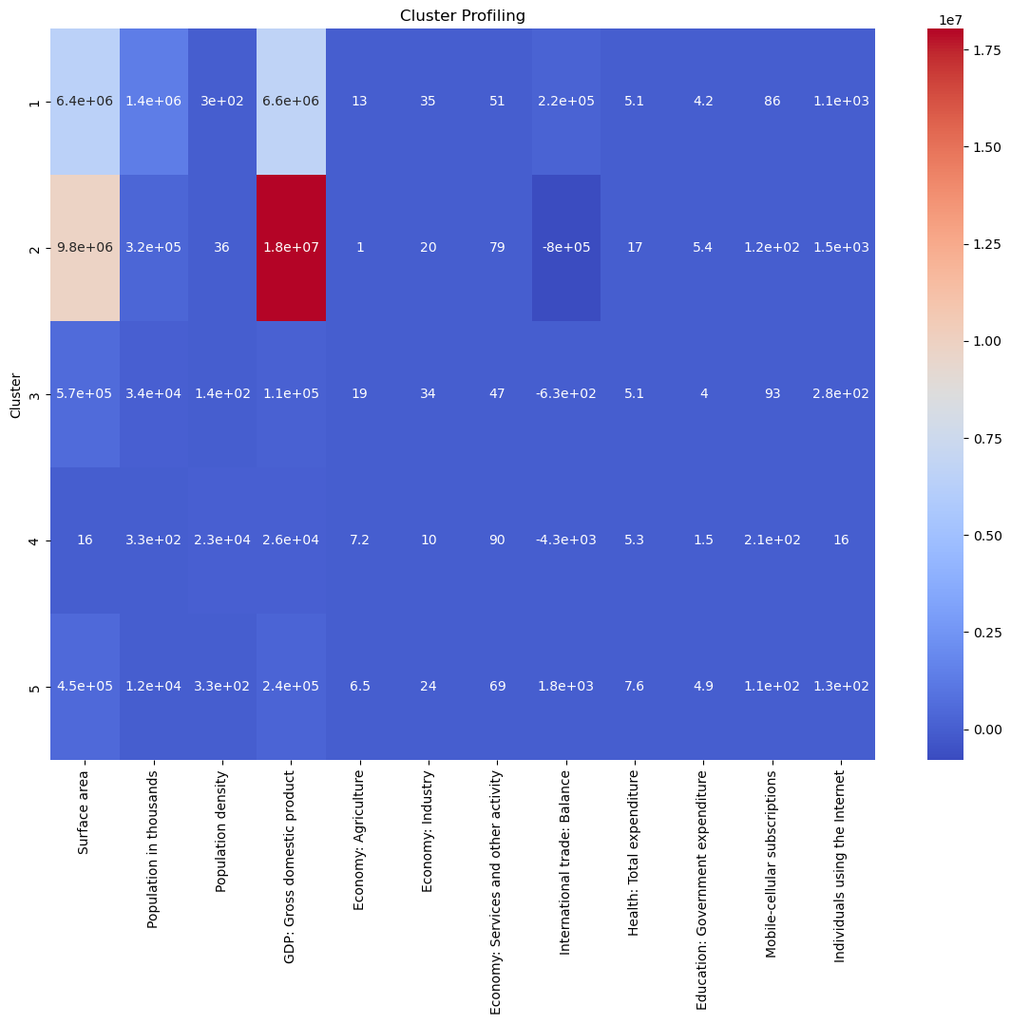

```python
cluster_profile = data[num_cols].groupby('Cluster').mean()

# Display the cluster profiling
print(cluster_profile)

# Optional: Visualize the cluster profiling
plt.figure(figsize=(14, 10))
sns.heatmap(cluster_profile, annot=True, cmap='coolwarm')
plt.title('Cluster Profiling')
plt.show()
```

#### Observations:

Cluster 3 includes smaller economies with balanced economic contributions but lower investments in health and education.

Cluster 4 features very small countries relying heavily on services with minimal investments in education and internet infrastructure.

Cluster 5 has moderate GDPs and diversified economies with balanced investments in health and education.

##### Business recommendations:

Focus on Technology and Innovation:

Invest in advanced technologies and innovation to maintain competitive advantage. Develop cutting-edge products and services in sectors such as AI, biotechnology, and clean energy.

Enhance Healthcare and Education:

Continue to invest in healthcare and education to improve quality and accessibility. Explore opportunities for digital health solutions and online education platforms.

Expand International Trade:

Strengthen trade relationships and explore new markets to further boost economic growth. Leverage trade agreements and partnerships to expand export opportunities.

Diversify the economy by investing in sectors beyond the dominant service industry. Promote growth in industries such as manufacturing, agriculture, and tourism.

Improve Trade Balance:

Implement policies to reduce trade deficits and enhance export competitiveness. Support local industries and encourage the production of high-value goods and services for export.

Invest in Social Infrastructure:

Increase investments in health and education to improve human capital and support long-term economic growth. Develop programs to enhance workforce skills and access to quality healthcare.

Cluster 3 (Smaller, Less Developed Economies): Agricultural Modernization:

Modernize the agricultural sector to increase productivity and sustainability. Introduce new technologies, improve supply chains, and provide training for farmers.

Strengthen Basic Infrastructure:

Invest in basic infrastructure such as transportation, energy, and communication. Improve access to essential services to support economic activities and enhance quality of life.

Develop Human Capital:

Focus on education and healthcare to build a skilled and healthy workforce. Implement programs to improve literacy rates, vocational training, and access to healthcare services.

Cluster 4 (Very Small Countries): Leverage Service Industry:

Capitalize on the strong service sector by promoting niche services such as tourism, finance, and specialized professional services. Develop marketing strategies to attract international clients and tourists.

Enhance Digital Connectivity:

Improve internet infrastructure to enhance digital connectivity and support remote work and online services. Foster a digital economy by encouraging e-commerce and digital entrepreneurship.

Strengthen Trade Relations:

Build strong trade relations with neighboring countries and global partners. Explore opportunities for regional trade agreements and collaborations.

Cluster 5 (Moderate Economies with Diverse Profiles): Promote Sustainable Development:

Focus on sustainable development initiatives to balance economic growth with environmental protection. Invest in renewable energy, sustainable agriculture, and conservation projects.

Boost Industrial Growth:

Support industrial growth by developing industrial parks, providing incentives for manufacturing, and improving supply chains. Encourage foreign direct investment in key industries.

Enhance Social Services:

Improve access to social services such as healthcare, education, and social security. Develop programs to support vulnerable populations and reduce income inequality.

#### Q5 A Apply PCA on the scaled data with 2 components.

#### Q5 B How much Cumulative Variance is Explained by 2 PCA’s?

#### Q5 C Plot a scatter plot on PCA’s formed

```
Explained variance by PC1: 0.20
Explained variance by PC2: 0.19
```

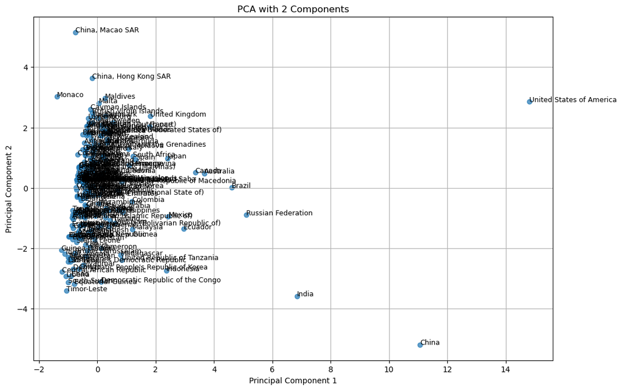

```python
from sklearn.decomposition import PCA

# Apply PCA with 2 components
pca = PCA(n_components=2)
pca_components = pca.fit_transform(data_for_model)

# Create a DataFrame with the PCA components
pca_df = pd.DataFrame(data=pca_components, columns=['PC1', 'PC2'])

# Add country names to the PCA DataFrame for better visualization
pca_df['Country'] = data['country']

# Display explained variance ratio
explained_variance = pca.explained_variance_ratio_
print(f'Explained variance by PC1: {explained_variance[0]:.2f}')
print(f'Explained variance by PC2: {explained_variance[1]:.2f}')

# Visualize the PCA components
plt.figure(figsize=(12, 8))
plt.scatter(pca_df['PC1'], pca_df['PC2'], alpha=0.7)
for i, country in enumerate(pca_df['Country']):
    plt.text(pca_df['PC1'][i], pca_df['PC2'][i], country, fontsize=9)
plt.xlabel('Principal Component 1')
plt.ylabel('Principal Component 2')
plt.title('PCA with 2 Components')
plt.grid(True)
plt.show()
```

#### Observations:

United States of America (USA): Positioned far to the right on PC1 and slightly high on PC2, suggesting unique socio-economic characteristics, likely a strong economy with high GDP and health expenditure.

China: Positioned far to the right on PC1, indicating significant variance from the central cluster, possibly due to its large population and rapid economic growth.

India: Positioned lower on PC1, indicating differences in socio-economic factors compared to China and the USA.

#### Q5 D Mention which are the major clusters. ( Hint: sns.scatterplot( data=reduced_df_pca, x="Component 1", y="Component 2", hue=df["HC_Clusters"], palette="rainbow")Above code is a hint, please use the names in which you have defined your functions).

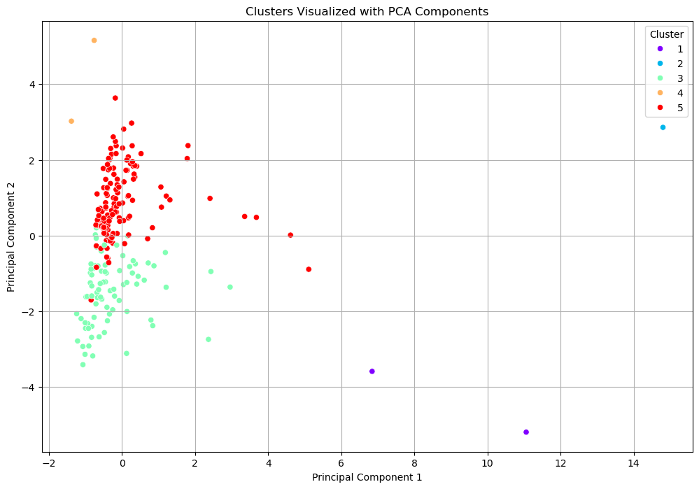

```python
pca_df['HC_Clusters'] = cluster_labels

# Visualize the clusters using PCA components
plt.figure(figsize=(12, 8))
sns.scatterplot(data=pca_df, x="PC1", y="PC2", hue=pca_df["HC_Clusters"], palette="rainbow")
plt.title('Clusters Visualized with PCA Components')
plt.xlabel('Principal Component 1')
plt.ylabel('Principal Component 2')
plt.legend(title='Cluster')
plt.grid(True)
plt.show()
```

#### Main clusters:

Cluster 3: Smaller, less developed economies.

Cluster 4: Very small, service-reliant economies.

Cluster 5: Moderate economies with diverse profiles.

#### Insights:

1. Cluster Separation:

Cluster 1 (Purple) and Cluster 2 (Blue) are distinctly separated from the other clusters, indicating that these groups of countries have unique socio-economic characteristics that set them apart.

Cluster 3 (Light Green) and Cluster 5 (Red) show significant overlap, suggesting that the countries within these clusters have similar socio-economic profiles with some differences.

2. Central Clusters:

Most data points are concentrated around the origin (0,0), particularly in Cluster 3 (Light Green) and Cluster 5 (Red). This suggests that a large number of countries share similar average socio-economic attributes.

3. Outliers and Unique Positions:

Cluster 4 (Orange) has data points scattered at higher values of Principal Component 2, indicating distinct socio-economic characteristics. These countries might have unique economic activities or demographic profiles that set them apart from the central clusters.

4. Principal Component Contributions:

Principal Component 1 (PC1) and Principal Component 2 (PC2) together capture the most significant variations in the data. Countries that are farthest along these components exhibit the most distinct socio-economic features compared to the others.

5. Economic and Social Diversity: